# Realimentação de estados

A principal técnico de controle em espaço de estados é o que chamamos de "realimentação de estados".

A estratégia básica é fazer a lei de controle $u$ ser proporcional ao vetor de estados. \begin{align*} u = -\mathbf{Kx} \end{align*}

Isto lembra um pouco o controle proporcional: realimentação negativa e o controlador é apenas uma constante. Mas a diferença básica é que, como o $\mathbf{x}$ é um vetor, o controlador $\mathbf{K}$ tem que ser um vetor também.

O sinal de controle é um escalar. Sendo $\mathbf{x}$ um vetor coluna de $n$ elementos, então $\mathbf{K}$ deve ser um vetor linha de $n$ elementos. Assim: \begin{align*} \mathbf{K}= \left[\begin{array}{cccc}K_1 & K_2 & \ldots & K_n\end{array}\right] \end{align*}

O objetivo inicial da realimentação de estados é fazer com que os estados do sistema caminhem para zero (ponto de equilíbrio) a partir de um estado inicial $\mathbf{x}(0)\neq \mathbf{0}$, em regime permanente (isto é, passado um longo tempo). Esse problema é chamado de **regulação**.

É possível mostra que se o controlador é capaz de fazer regulação de estados, podemos fazer a saída atingir qualquer valor, que é o objetivo do sistema de controle.

**Observação importante**: para o algoritmo funcionar supomos que **todos** os estados são conhecidos para calcular a ação de controle.

Isso quase sempre não é verdade. Os estados são grandezas internas que, às vezes, nem conseguimos medir. Mas mesmo quando é possível, pode não ser economicamente viável comprar sensores para medir todos os estados (um sistema de ordem elevada). O único sinal que está disponível, por definição, é o sinal de saída.

Na prática o que se faz é construir um sistema auxiliar que forneça uma *estimativa* dos estados reais a partir do sinal de saída. Esse sistema é conhecido como estimador ou observador de estados. O projeto e análise do observador de estados será visto mais a frente.

**Por enquanto vamos considerar que é possível medir todos os estados do sistema para fazer a realimentação**

## Análise da realimentação de estados

Para entender como projetar o controlador, precisamos entender o que acontece com o sistema quando a estratégia é implementada.

Seja um sistema: \begin{align*} \mathbf{\dot{x}} &= \mathbf{Ax+B}u \end{align*}

Se usarmos a lei de controle $u = -\mathbf{Kx}$, a equação deixará de ter entrada, podendo ser resolvida a partir da condição inicial.

\begin{align*} \mathbf{\dot{x}} &= \mathbf{Ax+B(-Kx)}\\ &= \mathbf{Ax-BKx}\\ &= \mathbf{(A-BK)x}\\ \mathbf{\dot{x}} &= \mathbf{A}_m \mathbf{x} \end{align*}

Vamos chamar matriz $\mathbf{A}_m$ de "matriz de malha fechada".

A última equação é uma EDO que não possui entrada, então só tem sentido resolvê-la para uma condição inicial $\mathbf{x}(0)$ diferente de zero.

A condição necessária para que os estados do sistema caminhem para zero em regime permanente é apenas que o sistema em malha fechada seja estável, isto é, **todos** os autovalores da matriz $\mathbf{A}_m$ devem ter parte real estritamente negativa.

Além de estabilidade, é também desejado que a convergência dos estados para zero seja feita com critérios de velocidade e oscilação específicos do projeto. Isso é equivalente a satisfazer as condições de overshoot, tempo de acomodação e dominância.

As condições de projeto são definidas em termos de pólos de malha fechada bem selecionados. Esses pólos determinam um polinômio de malha fechada $\alpha (s)$.

Sendo assim, o problema de regulação é enunciado como: *achar a matriz* $\mathbf{K}$, tal que estejam no semi-plano esquerdo todas as raizes da equação: \begin{align} \det (s\mathbf{I-A_m})= \det (s\mathbf{I-A+BK})=\alpha (s) \end{align}

[figure not shown]

Problema de segunda ordem, então: $\mathbf{K} = \begin{bmatrix} k_1 & k_2\end{bmatrix}$.

Matriz de malha fechada:

\begin{align} \mathbf{A-BK} = \left[\begin{matrix}0 & 1\\- \omega_{0}^{2} - k_{1} & - k_{2}\end{matrix}\right] \end{align}

Polinômio característico de malha fechada:

\begin{align} s\mathbf{I-A+BK}| = \omega_{0}^{2} + k_{1} + k_{2} s + s^{2} \end{align}

Polinômio mônico desejado, com dois polos em $-2\omega_0$:

\begin{align} \alpha(s) = 4 \omega_{0}^{2} + 4 \omega_{0} s + s^{2} \end{align}

Igualando termo a termo: \begin{align} k_1 + \omega_0^2 &= 4\omega_0^2 \Rightarrow k_1 = 3\omega_0^2\\ k_2 &= 4\omega_0 \end{align}

O livro mostra uma simulação da resposta desse sistema para $\omega_0=1$.

[figure not shown]

Repare que os gráficos mostram, em função do tempo, os dois estados. Note que nenhum dos sinais oscila. Isso porque as características dos pólos que foram alocados são válidas para todos os estados e a saída do sistema.

**Exercício**

Ache a forma de controlador do sistema \begin{align} G(s) = \frac{20}{(s+1)(s+2)} \end{align}

Depois, projete um controlador de realimentação de estados que posicione os pólos em $-3\pm j5$

## Forma canônica de controlador

O exemplo anterior ilustra bem a solução do problema de realimentação de estados. Porém, ele é simples demais:

- Ele é de ordem baixa (2). Na prática, os sistemas podem ser de ordem bem mais elevada
- Em um problema de ordem mais alta, o trabalho seria muito maior e a solução desenvolvida, inviável
- Além disso, em um problema real temos também que nos preocupar com questões numéricas de arredondamento.

A primeira forma de lidar com problemas de ordem mais alta é transformar o sistema para forma canônica de controlador.

Usar essa forma é vantajoso porque ela simplifica as equações dos ganhos na hora que igualamos os polinômios desejado e de projeto. Isso permite encontrar os ganhos com equações mais simples, geralmente fazendo substituições sucessivas.

Normalmente, a forma mais fácil de mudar para a forma de controlador é achando a função de transferência do sistema e usando as regras práticas de inspeção do numerador e denominador.

Isso pode ser um pouco trabalhoso para sistemas de ordem elevada.

## Método de Ackermann

Uma maneira mais direta e geral de projetar a realimentação de estados é usar o método de Ackerman. Ele consiste de aplicar a expressão: \begin{align} \mathbf{K} = \left[\begin{array}{ccccc}0&0&\ldots & 0 & 1\end{array}\right]\mathbf{\mathcal{C}}^{-1}\alpha_c(\mathbf{A}) \end{align}

onde $\mathbf{\mathcal{C}}$ é a chamada matriz de controlabilidade do sistema \begin{align} \mathbf{\mathcal{C}} = \left[\begin{array}{ccccc}\mathbf{B}&\mathbf{AB}&\ldots & \mathbf{A}^{n-2}\mathbf{B} & \mathbf{A}^{n-1}\mathbf{B}\end{array}\right] \end{align} e $\alpha_c(\mathbf{A})$ é uma matriz construída pela expressão: \begin{align} \alpha_c(\mathbf{A}) = \mathbf{A}^{n}+\alpha_1\mathbf{A}^{n-1}+\alpha_2\mathbf{A}^{n-2}+\ldots++\alpha_n\mathbf{I} \end{align}

Note que $\alpha_c(\mathbf{A})$ é o polinômio de malha fechado desejado, mas no lugar de $s$ temos a matriz $\mathbf{A}$ de malha aberta do sistema.

Observação: a solução do problema só existe se pudermos inverter a matriz de controlabilidade. Logo, a invertibilidade é condição necessária para o regulação do sistema. Normalmente, o primeiro passo de um projeto de controle é verificar se ele é controlável.

O método é trabalhoso, mas fácil de implementar no computador. Em Python temos a função "acker()" da biblioteca *control* que faz o processo automaticamente (sem precisar fornecer a forma de controlador), que funciona bem para sistemas de até 10a ordem e preferencialmente com pólos de malha fechada não-repetidos.

Para problemas mais complexos, recomenda-se o uso da função "place()" da biblioteca *control*, ou "place_poles()" da biblioteca *scipy.signal*.

Nota: essas funções só funcionam para problemas numéricos.

**Exemplo:**

[figure not shown]

Matriz de controlabilidade:

\begin{align} \mathcal{C} &= \begin{bmatrix} \mathbf{B} & | & \mathbf{AB}& \end{bmatrix} = \left[\begin{matrix}0 & 1\\1 & 0\end{matrix}\right] \end{align}

Inversa:

\begin{align} \mathcal{C}^{-1} &= \left[\begin{matrix}0 & 1\\1 & 0\end{matrix}\right] \end{align}

Note que, neste caso, a inversa é a própria matriz.

Matriz $\mathbf{A}$ aplicada ao polinômio $\alpha$:

\begin{align} \alpha(\mathbf{A}) = 4\omega_0^2\mathbf{I} + 4\omega_0 \mathbf{A} + \mathbf{A}^2 = \left[\begin{matrix}3 \omega_{0}^{2} & 4 \omega_{0}\\- 4 \omega_{0}^{3} & 3 \omega_{0}^{2}\end{matrix}\right] \end{align}

Fórmula de Ackerman:

\begin{align} \mathbf{K} = \begin{bmatrix} 0 & 1 \end{bmatrix} \, \left[\begin{matrix}0 & 1\\1 & 0\end{matrix}\right] \, \left[\begin{matrix}3 \omega_{0}^{2} & 4 \omega_{0}\\- 4 \omega_{0}^{3} & 3 \omega_{0}^{2}\end{matrix}\right] = \left[\begin{matrix}3 \omega_{0}^{2} & 4 \omega_{0}\end{matrix}\right] \end{align}

Solução numérica com Python:

```python
import control as ct
import numpy as np

w0 = 1
A = np.array([[0, 1],[-w0**2, 0]])
B = np.array([[0],[1]])
polos = [-2*w0, -2*w0]
K = ct.acker(A,B, polos)
print(K)
```

```
[[3. 4.]]
```

A fórmula de Ackermann permite posicionar os pólos de malha fechada **em qualquer lugar desejado**, desde que a matriz de controlabilidade possua inversa.

Isso torna o projeto mais direto, comparado por exemplo, ao método de projeto com LGR, onde o posicionamento dos pólos com controle roporcional fica restrito ao lugar geométrico.

No entanto, isso é possível devido à hipótese forte de que todos os estados estão disponíveis para realimentação.

**Exercício**

Use Ackermann para projetar um controlador para o sistema \begin{align} G(s) &= \frac{30}{s(s+1)^2} \end{align}

Posicione os pólos em $-4\pm j4$ e $-12$.

## Introdução da referência

Até agora vimos como resolver o problema da regulação de estados apenas para zerar o estado final. No entanto, o objetivo do controle é fazer a saída rastrear a referência $r$.

Uma forma simples de fazer isso é usando o sinal de controle: \begin{align*} u &= -\mathbf{Kx}+Nr \end{align*} onde $\mathbf{K}$ é o vetor de ganhos conforme já definimos e $N$ é um ganho a se determinar.

Se usarmos esta lei de controle, a equação de estados do sistema em malha fechada fica:

$$ \dot{\mathbf{x}} = \mathbf{(A-BK)x} + \mathbf{B}N\,r $$

A equação de saída fica: $$ y = (\mathbf{C}-D\mathbf{K})\mathbf{x}+DN\,r $$

A função de transferência do sistema da entrada de referência $r$ para a saída $y$ é:

$$ G(s) = (\mathbf{C}-D\mathbf{K})(s\mathbf{I-A+BK})^{-1}\mathbf{B}N+DN $$

Se quisermos que o sistema rastreie a referência em regime permanente, $y=r$, o ganho DC do sistema deve ser unitário, isto é, $G(0)=1$. Então fazemos $G(0)=1$ na equação e resolvemos para $N$. O resultado é:

$$ N = \frac{1}{(\mathbf{C}-D\mathbf{K})(\mathbf{-A+BK})^{-1}\mathbf{B}+D} $$

Como normalmente o ganho $D$ é nulo, temos o resultado mais usual:

$$ N = \frac{1}{\mathbf{C}(\mathbf{-A+BK})^{-1}\mathbf{B}} $$ O algoritmo de projeto é, portanto:

- Calcule o vetor de ganhos $\mathbf{K}$ normalmente, conforme as especificações de projeto
- Use o vetor $\mathbf{K}$ calculado para determinar $N$
- Implemente o algoritmo de controle como: $u=-\mathbf{Kx}+Nr$

[figure not shown]

Precisamos apenas usar a expressão: $$ N = \frac{1}{\mathbf{C}(\mathbf{-A+BK})^{-1}\mathbf{B}} $$ A saída do oscilador é a posição $x_1$, logo $\mathbf{C} = \begin{bmatrix}1 & 0\end{bmatrix}$. Usando o resultado anterior para $\mathbf{K}$.

\begin{align} \mathbf{-A+BK} &= \left[\begin{matrix}0 & -1\\4 \omega_{0}^{2} & 4 \omega_{0}\end{matrix}\right] \\ (\mathbf{-A+BK})^{-1} &= \left[\begin{matrix}\frac{1}{\omega_{0}} & \frac{1}{4 \omega_{0}^{2}}\\-1 & 0\end{matrix}\right]\\ N &= \frac{1}{ \mathbf{C} ( \mathbf{-A+BK})^{-1} \mathbf{B} } &= \frac{1}{ \frac{1}{4 \omega_{0}^{2}} } = 4 \omega_{0}^{2} \end{align}

## Simulação em malha fechada

É interessante testar o projeto agora usando uma resposta ao degrau. Note que para isso, precisamos definir o sistema em malha fechada.

Substituindo $u=-\mathbf{Kx}+Nr$ na equação de estados vemos que as matrizes $\mathbf{A}$ e $\mathbf{B}$ em malha fechada mudam. A saída permanence a mesma, logo a matriz $\mathbf{C}$ de malha fechada permanece a mesma.

Em malha fechada (i.e., ganhos realimentados), as equações do sistema ficam: \begin{align} \mathbf{\dot{x}} &= \mathbf{(A-BK)x} +\mathbf{B}Nr\\ y &= \mathbf{Cx} \end{align}

A seguir resolvemos e simulamos o sistema do exemplo anterior com $\omega_0=1$.

Imports e sistema

```python
import control as ct
import numpy as np

w0 = 1
A = np.array([[0, 1],[-w0**2, 0]])
B = np.array([[0],[1]])
C = np.array([[1,0]])
```

Alocação de pólos e referência

```python
polos = [-2*w0, -2*w0]
K = ct.acker(A,B, polos)
N = 1/(C @ np.linalg.inv(-A+B@K) @ B)
```

Matrizes de malha fechada. Repare o uso do símbolo @ para produto matricial.

```python
Amf = A - B@K
Bmf = B@N
Cmf = C
Dmf = np.array([[0]])
# Sistema
sis = ct.ss(Amf,Bmf,Cmf,Dmf)
```

Relatório de pólos de malha fechada

```python
tab = ct.damp(sis)
```

```
    Eigenvalue (pole)       Damping     Frequency
                   -2             1             2
                   -2             1             2
```

Os pólos foram corretamente alocados. Repare que, por serem reais, o programa considera amortecimento (*damping*) igual a 1 e a frequência natural é o módulo do pólo.

Zeros de transmissão

```python
ct.zeros(sis)
```

```
array([], dtype=complex128)
```

O sistema não possui zeros.

Simula o sistema para uma resposta ao degrau unitário. Tempo de simulação é 7 segundos.

```python
t,y = ct.step_response(sis,7)
```

Plota os resultados, com algumas legendas

[figure not shown]

```python
t,y = ct.step_response(sis,7)
import matplotlib.pyplot as plt
plt.figure(figsize=(10,3))
plt.plot(t,y)
plt.grid()
plt.xlabel('Tempo (seg)')
plt.ylabel('Saída')
plt.legend('y')
plt.show()
```

## Escolha dos pólos

O sucesso do controle depende da escolha adequada do polinômio de malha fechada desejado. Esse polinômio deve ser construído tendo em mente todos os pólos de malha fechada desejados, não apenas os dominantes.

Isso é importante quando temos um sistema de ordem maior que 2: os pólos que não serão dominantes devem ser escolhidos suficientemente distantes dos candidatos a dominantes.

Uma regra prática é, após escolher os dominantes, escolher os demais como reais, com a parte real de 3 a 5 vezes maior que a parte real dos dominantes.

Lembre-se, porém, que se o deslocamento dos polos para a nova posição for muito grande, os ganhos do controlador vão aumentar e consequentemente o sinal de controle vai exigir mais energia.

Outra coisa a se ter em mente na hora de escolher pólos de malha fechada são os zeros do sistema. **A realimentação de estados não altera a posição dos zeros**, isto é, se eles não forem cancelados, eles permanecerão na mesma posição em malha fechada. Agora, se estes zeros estiverem próximos dos pólos dominantes em malha fechada, a dinâmica projetada não irá funcionar corretamente (normalmente o overshoot será mais alto do que o projetado).

Uma forma de lidar com isso é posicionar um pólo extra sobre o zero que está atrapalhando o projeto, mas **apenas se o zero for estável**.

Note que devido às incertezas e os arredondamentos de projeto, podemos ter que fazer novas escolhas de polos até achar uma combinação que se ajuste ao que precisamos.

[figure not shown]

Observe a solução com Python.

```python
# Imports
import control as ct
import numpy as np

# Sistema
A = np.array([  [0, 2, 0, 0, 0],
                [-.1, -.35, .1, .1, .75],
                [0, 0, 0, 2, 0],
                [.4, .4, -.4, -1.4, 0],
                [0, -.03, 0, 0, -1]     ],dtype=float)
B = np.array([[0],[0],[0],[0],[1]])
C = np.array([[1,0,0,0,0]])
D = np.array([[0]])
```

Pólos desejados, calculados pelos parâmetros físicos

```python
xi = 0.707
wn = 1/1.15
p = -xi*wn+1j*wn*np.sqrt(1-xi**2)
```

Polos de malha fechada desejados, conjunto completo. Note a forma de gerar os pólos adicionais usando o dominante como referência e o recurso de repetição de elementos de uma lista.

```python
polos_dom = np.array([[p, np.conjugate(p)]])
polos_extras = np.array([[np.real(p)*4]*3])
polos_mf = np.block([polos_dom,polos_extras])
```

Alocação de polos e referência

```python
K = ct.acker(A,B,polos_mf[0,:])
N = 1/(C @ np.linalg.inv(-A+B@K) @ B)
```

O vetor de ganhos encontrado é:
$$\mathbf{K} = \left[\begin{matrix}8.1 & 19.33 & 1.27 & -0.2139 & 5.857\end{matrix}\right]$$

**Os valores são um pouco diferentes do livro. Tente descobrir a razão**

Simulação em malha fechada:

```python
Amf = A - B@K
Bmf = B@N
Cmf = C
Dmf = np.array([[0]])

# Sistema
sis = ct.ss(Amf,Bmf,Cmf,Dmf)

# Simulação
t,y = ct.step_response(sis,7)
```

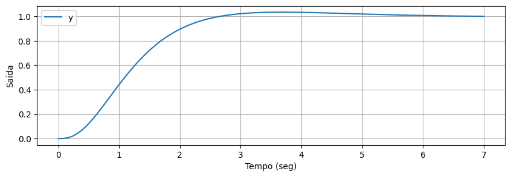

```python
plt.figure(figsize=(10,3))
plt.plot(t,y)
plt.grid()
plt.xlabel('Tempo (seg)')
plt.ylabel('Saída')
plt.legend('y')
plt.show()
```

É sempre importante analisar as características do sistema (pólos e zeros), além dos sinais.

```python
tab = ct.damp(sis)
```

```
    Eigenvalue (pole)       Damping     Frequency
               -2.459             1         2.459
    -2.459 +2.17e-05j             1         2.459
    -2.459 -2.17e-05j             1         2.459
   -0.6148    +0.615j         0.707        0.8696
   -0.6148    -0.615j         0.707        0.8696
```

Zeros:

```python
sis.zeros()
```

```
array([-0.7+0.55677644j, -0.7-0.55677644j])
```

Valor máximo de saída:

```python
print(max(y))
```

```
1.0339565325466082
```

[figure not shown]

```python
# Imports
import control as ct
import numpy as np

z0 = 2.

# Declaração das matrizes e do sistema
A = np.array([[-7,1],[-12,0]])
B = np.array([[1],[-z0]])
C = np.array([[1,0]])
D = np.array([[0]])
sys = ct.ss(A,B,C,D)

# Pólos desejados
xi = 0.5
wn = 2
polo = wn*(-xi+1j*np.sqrt(1-xi**2))

# Alocação de polos
K = ct.acker(A,B,[polo, np.conj(polo)])
```

Regulador encontrado: $\mathbf{K}= \left[\begin{matrix}-3.8 & 0.6\end{matrix}\right]$

Quando um polo e um zero tendem a se cancelar, o sistema tende a perder controlabilidade e isso torna os ganhos mais altos e, consequentemente, o controle fica mais "caro" (puxa mais energia). Vale a observação do livro:

**"O sistema tem que trabalhar com mais força para conseguir o controle quando a controlabilidade é fraca."**

Além disso:

**"Mover os polos em um longo caminho requer grandes ganhos."**

Isso é observado quando um sistema é naturalmente lento e tentamos deixá-lo mais rápido. Isso normalmente resulta em ganhos grandes (em módulo), o que resulta novamente em um controle "caro".